# IGPL

## 1 Datasets

|  | Dataset | #Stakeholders | #PBI |
| --- | --- | --- | --- |
| 0 | p1 | 5 | 18 |
| 1 | p2 | 5 | 96 |
| 2 | s1 | 15 | 40 |
| 3 | s2 | 50 | 80 |
| 4 | s3 | 100 | 140 |
| 5 | s4 | 150 | 200 |

## 2 Search of the best hyperparameters configuration for each algorithm, given SSS_per_iteration={False,True}

### 2.0 Best configuration for: AGEMOEA2

[output not shown]

|  | population_length | max_generations | sss_per_iteration | datasets | HV | time | wins |
| --- | --- | --- | --- | --- | --- | --- | --- |
| 0 | 100 | 200 | False | [p1] | [0.9864] | [34.65] | 1.000 |
| 1 | 200 | 400 | False | [p2] | [0.8623] | [443.61] | 1.000 |
| 2 | 500 | 400 | False | [s1] | [0.8865] | [1067.13] | 1.000 |
| 3 | 1000 | 400 | False | [s2] | [0.8111] | [5742.28] | 1.000 |
| 4 | 700 | 400 | False | [s3, s4] | [0.8154, 0.7597] | [4480.77, 5110.93] | 2.000 |

[output not shown]

|  | population_length | max_generations | sss_per_iteration | datasets | HV | time | wins |
| --- | --- | --- | --- | --- | --- | --- | --- |
| 0 | 200 | 100 | True | [p1] | [0.9864] | [28.86] | 1.000 |
| 1 | 200 | 400 | True | [p2] | [0.8623] | [260.49] | 1.000 |
| 2 | 500 | 400 | True | [s1] | [0.8866] | [758.39] | 1.000 |
| 3 | 1000 | 400 | True | [s2] | [0.8111] | [2610.53] | 1.000 |
| 4 | 700 | 400 | True | [s3, s4] | [0.8153, 0.7595] | [1548.83, 1546.19] | 2.000 |

```
Best hyperparameter configuration for AGEMOEA2 is:
population_length:700
max_generations:400
sss_per_iteration:True
```

### 2.1 Best configuration for: GeneticNDS

[output not shown]

|  | population_length | max_generations | selection_candidates | crossover_prob | mutation_prob | mutation | replacement | sss_per_iteration | datasets | HV | time | wins |
| --- | --- | --- | --- | --- | --- | --- | --- | --- | --- | --- | --- | --- |
| 0 | 1000 | 300 | 2 | 0.8 | 0.1 | flip1bit | elitismnds | False | [p1] | [0.9574] | [722.19] | 1.000 |
| 1 | 1000 | 400 | 2 | 0.8 | 0.1 | flip1bit | elitismnds | False | [p2, s1, s4] | [0.7124, 0.783, 0.6475] | [2060.48, 2014.94, 3531.49] | 3.000 |
| 2 | 1000 | 100 | 2 | 0.8 | 0.1 | flip1bit | elitismnds | False | [s2, s3] | [0.6848, 0.6831] | [586.46, 566.44] | 2.000 |

[output not shown]

|  | population_length | max_generations | selection_candidates | crossover_prob | mutation_prob | mutation | replacement | sss_per_iteration | datasets | HV | time | wins |
| --- | --- | --- | --- | --- | --- | --- | --- | --- | --- | --- | --- | --- |
| 0 | 1000 | 300 | 2 | 0.8 | 0.1 | flip1bit | elitismnds | True | [p1, s3] | [0.9572, 0.6828] | [224.76, 262.53] | 2.000 |
| 1 | 1000 | 400 | 2 | 0.8 | 0.1 | flip1bit | elitismnds | True | [p2, s1, s4] | [0.7121, 0.7827, 0.6472] | [378.99, 278.47, 384.87] | 3.000 |
| 2 | 1000 | 100 | 2 | 0.8 | 0.1 | flip1bit | elitismnds | True | [s2] | [0.6846] | [83.78] | 1.000 |

```
Best hyperparameter configuration for GeneticNDS is:
population_length:1000
max_generations:400
selection_candidates:2
crossover_prob:0.8
mutation_prob:0.1
mutation:flip1bit
replacement:elitismnds
sss_per_iteration:True
```

### 2.2 Best configuration for: UMDA

[output not shown]

|  | population_length | max_generations | selection_scheme | replacement_scheme | sss_per_iteration | datasets | HV | time | wins |
| --- | --- | --- | --- | --- | --- | --- | --- | --- | --- |
| 0 | 1000 | 50 | nds | elitism | False | [p1, s3, s4] | [0.9836, 0.7913, 0.7635] | [107.34, 610.31, 693.92] | 3.000 |
| 1 | 1000 | 100 | nds | elitism | False | [p2] | [0.8193] | [808.83] | 1.000 |
| 2 | 1000 | 400 | nds | elitism | False | [s1, s2] | [0.8542, 0.7782] | [1981.44, 4993.04] | 2.000 |

[output not shown]

|  | population_length | max_generations | selection_scheme | replacement_scheme | sss_per_iteration | datasets | HV | time | wins |
| --- | --- | --- | --- | --- | --- | --- | --- | --- | --- |
| 0 | 1000 | 50 | nds | elitism | True | [p1, s3] | [0.9835, 0.7897] | [80.48, 305.48] | 2.000 |
| 1 | 1000 | 100 | nds | elitism | True | [p2, s4] | [0.8176, 0.7619] | [393.53, 668.13] | 2.000 |
| 2 | 1000 | 400 | nds | elitism | True | [s1, s2] | [0.8542, 0.7768] | [1149.43, 1814.04] | 2.000 |

```
Best hyperparameter configuration for UMDA when sss_per_iteration=True:
population_length:1000
max_generations:400
selection_scheme:nds
replacement_scheme:elitism
sss_per_iteration:True
```

### 2.3 Best configuration for: PBIL

[output not shown]

|  | population_length | max_generations | max_evaluations | learning_rate | mutation_prob | mutation_shift | sss_per_iteration | datasets | HV | time | wins |
| --- | --- | --- | --- | --- | --- | --- | --- | --- | --- | --- | --- |
| 0 | 1000 | 400 | 0 | 0.1 | 0.1 | 0.1 | False | [p1, p2, s1, s3, s4] | [0.9908, 0.6018, 0.81, 0.5442, 0.4819] | [496.32, 567.83, 828.06, 616.63, 635.95] | 5.000 |
| 1 | 500 | 400 | 0 | 0.1 | 0.1 | 0.1 | False | [s2] | [0.5891] | [369.92] | 1.000 |

[output not shown]

|  | population_length | max_generations | max_evaluations | learning_rate | mutation_prob | mutation_shift | sss_per_iteration | datasets | HV | time | wins |
| --- | --- | --- | --- | --- | --- | --- | --- | --- | --- | --- | --- |
| 0 | 1000 | 400 | 0 | 0.1 | 0.1 | 0.1 | True | [p1, p2, s1, s2] | [0.9929, 0.7011, 0.8423, 0.6695] | [229.73, 190.3, 250.5, 268.28] | 4.000 |
| 1 | 700 | 400 | 0 | 0.1 | 0.1 | 0.1 | True | [s3, s4] | [0.6093, 0.5472] | [141.96, 151.48] | 2.000 |

```
Best hyperparameter configuration for PBIL is:
population_length:1000
max_generations:400
max_evaluations:0
learning_rate:0.1
mutation_prob:0.1
mutation_shift:0.1
sss_per_iteration:True
```

### 2.4 Best configuration for: MIMIC

[output not shown]

|  | population_length | max_generations | max_evaluations | selection_scheme | selected_individuals | sss_per_iteration | datasets | HV | time | wins |
| --- | --- | --- | --- | --- | --- | --- | --- | --- | --- | --- |
| 0 | 500 | 300 | 0 | nds | 50 | False | [p1] | [0.9931] | [326.25] | 1.000 |
| 1 | 1000 | 400 | 0 | nds | 50 | False | [p2, s1, s2, s3, s4] | [0.8601, 0.8806, 0.7967, 0.8208, 0.7827] | [5401.82, 2024.31, 5246.0, 9353.97, 9681.63] | 5.000 |

[output not shown]

|  | population_length | max_generations | max_evaluations | selection_scheme | selected_individuals | sss_per_iteration | datasets | HV | time | wins |
| --- | --- | --- | --- | --- | --- | --- | --- | --- | --- | --- |
| 0 | 500 | 300 | 0 | nds | 50 | True | [p1] | [0.9931] | [279.24] | 1.000 |
| 1 | 1000 | 400 | 0 | nds | 50 | True | [p2, s1, s2, s3, s4] | [0.8593, 0.8804, 0.7956, 0.8197, 0.7791] | [4285.15, 1707.36, 3895.74, 5017.7, 6872.74] | 5.000 |

```
Best hyperparameter configuration for MIMIC is:
population_length:1000
max_generations:400
max_evaluations:0
selection_scheme:nds
selected_individuals:50
sss_per_iteration:True
```

### 2.5 Best configuration for: nsgaii

[output not shown]

|  | population_length | max_generations | selection_candidates | crossover_prob | mutation_prob | mutation | replacement | sss_per_iteration | datasets | HV | time | wins |
| --- | --- | --- | --- | --- | --- | --- | --- | --- | --- | --- | --- | --- |
| 0 | 100 | 200 | 2 | 0.8 | 0.1 | flip1bit | elitism | False | [p1] | [0.9931] | [431.77] | 1.000 |
| 1 | 700 | 400 | 2 | 0.8 | 0.1 | flip1bit | elitism | False | [p2] | [0.8873] | [40789.71] | 1.000 |
| 2 | 200 | 300 | 2 | 0.8 | 0.1 | flip1bit | elitism | False | [s1] | [0.8867] | [2416.33] | 1.000 |
| 3 | 1000 | 400 | 2 | 0.8 | 0.1 | flip1bit | elitism | False | [s2, s3, s4] | [0.8211, 0.8634, 0.8231] | [75621.66, 76065.29, 75704.89] | 3.000 |

```
Best hyperparameter configuration for NSGA-II is:
population_length:1000
max_generations:400
selection_candidates:2
crossover_prob:0.8
mutation_prob:0.1
mutation:flip1bit
replacement:elitism
sss_per_iteration:False
```

## 3 Plots of algorithms' NDS with their best configuration

### 3.1 Original SSS (only at the end)

```
p1
Pareto Reference has 52 points
Maximum UNFR possible is 10/52=0.1923
```

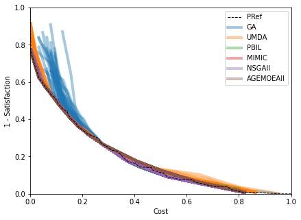

|  | Method | HV | UNFR | spread | time(s) | \|NDS\| |
| --- | --- | --- | --- | --- | --- | --- |
| 0 | geneticNDS | 0.9564 | 0.1391 | 0.6267 | 999.7573 | 48.4000 |
| 1 | umda | 0.9836 | 0.1654 | 0.5828 | 107.3422 | 43.9333 |
| 2 | pbil | 0.9908 | 0.1910 | 0.5456 | 496.3192 | 49.1667 |
| 3 | mimic | 0.9931 | 0.1923 | 0.5190 | 906.5714 | 55.0000 |
| 4 | nsgaii | 0.9931 | 0.1923 | 0.5190 | 48718.3532 | 1000.0000 |
| 5 | agemoea2 | 0.9864 | 0.1154 | 0.6391 | 805.4881 | 39.0000 |

```
---------------------------------------------------------------
p2
Pareto Reference has 544 points
Maximum UNFR possible is 10/544=0.0184
```

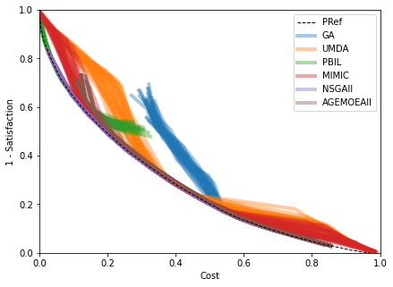

|  | Method | HV | UNFR | spread | time(s) | \|NDS\| |
| --- | --- | --- | --- | --- | --- | --- |
| 0 | geneticNDS | 0.7124 | 0.0037 | 0.7074 | 2060.4812 | 99.3667 |
| 1 | umda | 0.8190 | 0.0044 | 0.6123 | 391.3572 | 165.1667 |
| 2 | pbil | 0.6018 | 0.0034 | 0.5908 | 567.8328 | 84.7000 |
| 3 | mimic | 0.8601 | 0.0074 | 0.5836 | 5401.8163 | 332.9667 |
| 4 | nsgaii | 0.8870 | 0.0172 | 0.6742 | 79464.9200 | 1000.0000 |
| 5 | agemoea2 | 0.8543 | 0.0018 | 0.5871 | 2209.7099 | 423.1333 |

```
---------------------------------------------------------------
s1
Pareto Reference has 215 points
Maximum UNFR possible is 10/215=0.0465
```

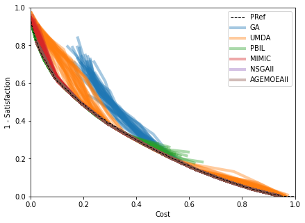

|  | Method | HV | UNFR | spread | time(s) | \|NDS\| |
| --- | --- | --- | --- | --- | --- | --- |
| 0 | geneticNDS | 0.7830 | 0.0167 | 0.6262 | 2014.9437 | 101.8333 |
| 1 | umda | 0.8540 | 0.0234 | 0.6061 | 247.4566 | 98.8667 |
| 2 | pbil | 0.8100 | 0.0384 | 0.5930 | 828.0578 | 112.8667 |
| 3 | mimic | 0.8806 | 0.0374 | 0.5891 | 2024.3122 | 189.1000 |
| 4 | nsgaii | 0.8866 | 0.0465 | 0.5295 | 72602.3069 | 1000.0000 |
| 5 | agemoea2 | 0.8865 | 0.0464 | 0.5283 | 1607.4865 | 214.8000 |

```
---------------------------------------------------------------
s2
Pareto Reference has 806 points
Maximum UNFR possible is 10/806=0.0124
```

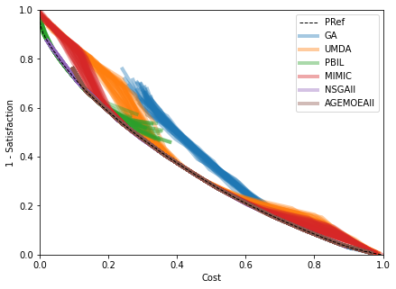

|  | Method | HV | UNFR | spread | time(s) | \|NDS\| |
| --- | --- | --- | --- | --- | --- | --- |
| 0 | geneticNDS | 0.6841 | 0.0028 | 0.6300 | 3158.8015 | 154.6667 |
| 1 | umda | 0.7719 | 0.0029 | 0.6240 | 495.1797 | 245.7667 |
| 2 | pbil | 0.5858 | 0.0055 | 0.5861 | 869.2547 | 173.1667 |
| 3 | mimic | 0.7967 | 0.0049 | 0.5911 | 5246.0015 | 421.7333 |
| 4 | nsgaii | 0.8211 | 0.0122 | 0.5975 | 75621.6595 | 1000.0000 |
| 5 | agemoea2 | 0.8080 | 0.0112 | 0.6108 | 3523.0145 | 784.0333 |

```
---------------------------------------------------------------
s3
Pareto Reference has 985 points
Maximum UNFR possible is 10/985=0.0102
```

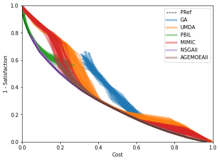

|  | Method | HV | UNFR | spread | time(s) | \|NDS\| |
| --- | --- | --- | --- | --- | --- | --- |
| 0 | geneticNDS | 0.6817 | 0.0015 | 0.6967 | 3095.1434 | 151.3333 |
| 1 | umda | 0.7913 | 0.0016 | 0.5732 | 610.3098 | 292.0000 |
| 2 | pbil | 0.5442 | 0.0005 | 0.5664 | 616.6283 | 76.6000 |
| 3 | mimic | 0.8208 | 0.0039 | 0.5891 | 9353.9743 | 561.1667 |
| 4 | nsgaii | 0.8634 | 0.0093 | 0.6025 | 76065.2905 | 1000.0000 |
| 5 | agemoea2 | 0.8154 | 0.0071 | 0.6140 | 4480.7695 | 882.9000 |

```
---------------------------------------------------------------
s4
Pareto Reference has 1112 points
Maximum UNFR possible is 10/1112=0.0090
```

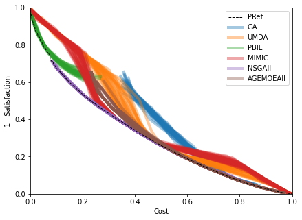

|  | Method | HV | UNFR | spread | time(s) | \|NDS\| |
| --- | --- | --- | --- | --- | --- | --- |
| 0 | geneticNDS | 0.6475 | 0.0011 | 0.6928 | 3531.4942 | 181.3667 |
| 1 | umda | 0.7635 | 0.0012 | 0.5717 | 693.9228 | 359.8333 |
| 2 | pbil | 0.4819 | 0.0008 | 0.5985 | 635.9512 | 70.1333 |
| 3 | mimic | 0.7827 | 0.0019 | 0.6050 | 9681.6318 | 614.9000 |
| 4 | nsgaii | 0.8231 | 0.0079 | 0.6179 | 75704.8851 | 1000.0000 |
| 5 | agemoea2 | 0.7597 | 0.0038 | 0.6065 | 5110.9340 | 922.7667 |

```
---------------------------------------------------------------
Wins Counts:
{'geneticNDS': 0, 'umda': 0, 'pbil': 0, 'mimic': 1, 'nsgaii': 5, 'agemoea2': 0}
Wins in datasets:
{'geneticNDS': [], 'umda': [], 'pbil': [], 'mimic': ['p1'], 'nsgaii': ['p2', 's1', 's2', 's3', 's4'], 'agemoea2': []}
Wins Counts UNFR:
{'geneticNDS': 0, 'umda': 0, 'pbil': 0, 'mimic': 1, 'nsgaii': 5, 'agemoea2': 0}
Wins Counts Spread:
{'geneticNDS': 0, 'umda': 1, 'pbil': 2, 'mimic': 2, 'nsgaii': 0, 'agemoea2': 1}
```

### 3.2 SSS per iteration

```
p1
Pareto Reference has 52 points
Maximum UNFR possible is 10/52=0.1923
```

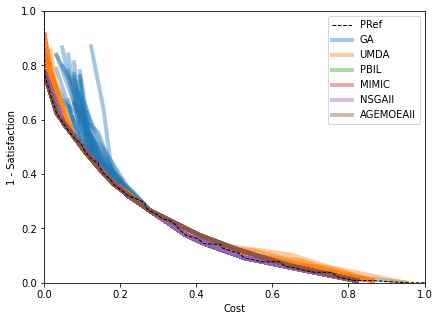

|  | Method | HV | UNFR | spread | time(s) | \|NDS\| |
| --- | --- | --- | --- | --- | --- | --- |
| 0 | geneticNDS | 0.9563 | 0.1417 | 0.6345 | 314.9184 | 10.0000 |
| 1 | umda | 0.9835 | 0.1654 | 0.5837 | 80.4805 | 10.0000 |
| 2 | pbil | 0.9929 | 0.1923 | 0.5191 | 229.7266 | 10.0000 |
| 3 | mimic | 0.9931 | 0.1923 | 0.5190 | 700.9948 | 10.0000 |
| 4 | nsgaii | 0.9931 | 0.1923 | 0.5190 | 48718.3532 | 1000.0000 |
| 5 | agemoea2 | 0.9863 | 0.1154 | 0.6387 | 631.9953 | 10.0000 |

```
---------------------------------------------------------------
p2
Pareto Reference has 544 points
Maximum UNFR possible is 10/544=0.0184
```

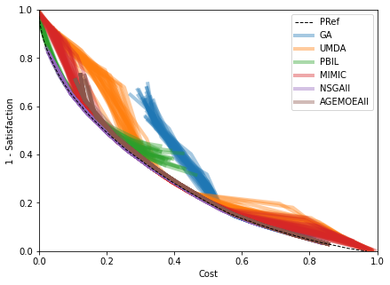

|  | Method | HV | UNFR | spread | time(s) | \|NDS\| |
| --- | --- | --- | --- | --- | --- | --- |
| 0 | geneticNDS | 0.7121 | 0.0046 | 0.7202 | 378.9891 | 10.0000 |
| 1 | umda | 0.8173 | 0.0050 | 0.6633 | 188.5185 | 10.0000 |
| 2 | pbil | 0.7011 | 0.0004 | 0.5872 | 190.3026 | 10.0000 |
| 3 | mimic | 0.8593 | 0.0083 | 0.6177 | 4285.1495 | 10.0000 |
| 4 | nsgaii | 0.8870 | 0.0172 | 0.6742 | 79464.9200 | 1000.0000 |
| 5 | agemoea2 | 0.8542 | 0.0018 | 0.6154 | 1320.2074 | 10.0000 |

```
---------------------------------------------------------------
s1
Pareto Reference has 215 points
Maximum UNFR possible is 10/215=0.0465
```

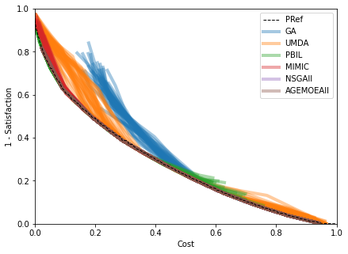

|  | Method | HV | UNFR | spread | time(s) | \|NDS\| |
| --- | --- | --- | --- | --- | --- | --- |
| 0 | geneticNDS | 0.7827 | 0.0180 | 0.6332 | 278.4679 | 10.0000 |
| 1 | umda | 0.8538 | 0.0242 | 0.6119 | 143.6023 | 10.0000 |
| 2 | pbil | 0.8423 | 0.0378 | 0.5710 | 250.4972 | 10.0000 |
| 3 | mimic | 0.8804 | 0.0375 | 0.5879 | 1707.3619 | 10.0000 |
| 4 | nsgaii | 0.8866 | 0.0465 | 0.5295 | 72602.3069 | 1000.0000 |
| 5 | agemoea2 | 0.8864 | 0.0456 | 0.5321 | 1100.7276 | 10.0000 |

```
---------------------------------------------------------------
s2
Pareto Reference has 806 points
Maximum UNFR possible is 10/806=0.0124
```

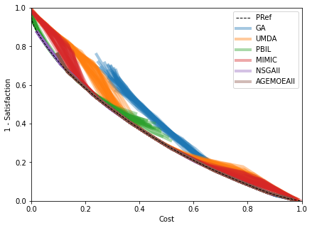

|  | Method | HV | UNFR | spread | time(s) | \|NDS\| |
| --- | --- | --- | --- | --- | --- | --- |
| 0 | geneticNDS | 0.6839 | 0.0032 | 0.6368 | 311.5642 | 10.0000 |
| 1 | umda | 0.7707 | 0.0032 | 0.6249 | 236.1065 | 10.0000 |
| 2 | pbil | 0.6695 | 0.0025 | 0.5916 | 268.2806 | 10.0000 |
| 3 | mimic | 0.7956 | 0.0054 | 0.5960 | 3895.7363 | 10.0000 |
| 4 | nsgaii | 0.8211 | 0.0122 | 0.5975 | 75621.6595 | 1000.0000 |
| 5 | agemoea2 | 0.8079 | 0.0111 | 0.6098 | 1708.3488 | 10.0000 |

```
---------------------------------------------------------------
s3
Pareto Reference has 985 points
Maximum UNFR possible is 10/985=0.0102
```

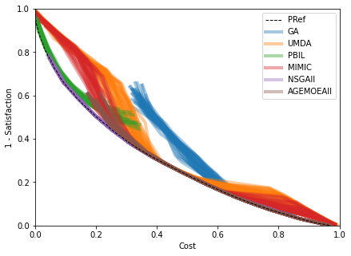

|  | Method | HV | UNFR | spread | time(s) | \|NDS\| |
| --- | --- | --- | --- | --- | --- | --- |
| 0 | geneticNDS | 0.6814 | 0.0020 | 0.7012 | 343.5425 | 10.0000 |
| 1 | umda | 0.7897 | 0.0019 | 0.6097 | 305.4827 | 10.0000 |
| 2 | pbil | 0.6085 | 0.0001 | 0.5791 | 202.7360 | 10.0000 |
| 3 | mimic | 0.8197 | 0.0044 | 0.6050 | 5017.6957 | 10.0000 |
| 4 | nsgaii | 0.8634 | 0.0093 | 0.6025 | 76065.2905 | 1000.0000 |
| 5 | agemoea2 | 0.8153 | 0.0070 | 0.6040 | 1548.8266 | 10.0000 |

```
---------------------------------------------------------------
s4
Pareto Reference has 1112 points
Maximum UNFR possible is 10/1112=0.0090
```

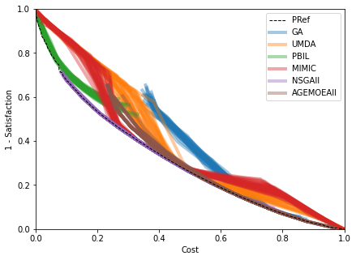

|  | Method | HV | UNFR | spread | time(s) | \|NDS\| |
| --- | --- | --- | --- | --- | --- | --- |
| 0 | geneticNDS | 0.6472 | 0.0016 | 0.6937 | 384.8667 | 10.0000 |
| 1 | umda | 0.7614 | 0.0014 | 0.5943 | 294.2107 | 10.0000 |
| 2 | pbil | 0.5469 | 0.0003 | 0.6076 | 217.6748 | 10.0000 |
| 3 | mimic | 0.7791 | 0.0023 | 0.6340 | 6872.7360 | 10.0000 |
| 4 | nsgaii | 0.8231 | 0.0079 | 0.6179 | 75704.8851 | 1000.0000 |
| 5 | agemoea2 | 0.7595 | 0.0037 | 0.6074 | 1546.1942 | 10.0000 |

```
---------------------------------------------------------------
Wins Counts:
{'geneticNDS': 0, 'umda': 0, 'pbil': 0, 'mimic': 1, 'nsgaii': 5, 'agemoea2': 0}
Wins in datasets:
{'geneticNDS': [], 'umda': [], 'pbil': [], 'mimic': ['p1'], 'nsgaii': ['p2', 's1', 's2', 's3', 's4'], 'agemoea2': []}
Wins Counts UNFR:
{'geneticNDS': 0, 'umda': 0, 'pbil': 1, 'mimic': 0, 'nsgaii': 5, 'agemoea2': 0}
Wins Counts Spread:
{'geneticNDS': 0, 'umda': 1, 'pbil': 3, 'mimic': 1, 'nsgaii': 1, 'agemoea2': 0}
```

## 4 Changes in Time, HV and GD+

Given the most frequently best configuration (over all datasets), we plot the pareto for each dataset given that configuration. That is, the configuration for a given algorithm is the same acrooss all datasets, concretely the one which performed the best more times (more wins).

We show a plot for each dataset. In each plot, for each algorithm, we show the pareto front found in all the executions (commonly 30). Since the solutions subset size is commonly 10, thus for each algorithm we plot 300 points. Since each algorithm has 30 paretos, please note that such paretos are not non-dominated among them, which can be seen in the shapes they create.

Here we show one plot pero datasets, containing the result of all algorithms with their best configuration. As mentioned before, each algorithm is run 30 times; afeter each execution, we keep a subset of the NDS constructed. This subset contains the 10 solutions from NDS which maximize HV in a forward greedy search over the NDS. Thus, for each algorithm, we plot 10*30=300 points. This way, it is easy to identify the common pareto shape relative to the algorithm. After each plot, all metrics are tabbed to show the average over the 30 executions in the dataset.

#### 4.1 Total time of algorithms and what part is used for updating the NDS_archive

```
Mean percentage of total time used to update NDS_archive in each algorithm. Dataset: p1.
geneticNDS: 91.01%
umda: 68.32%
pbil: 84.96%
mimic: 57.37%
nsgaii: 18.03%
agemoea2: 38.86%
```

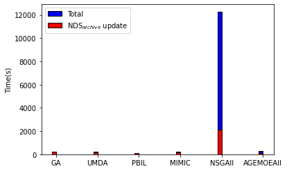

```
Mean percentage of total time used to update NDS_archive in each algorithm. Dataset: p2.
geneticNDS: 94.25%
umda: 79.36%
pbil: 86.46%
mimic: 41.41%
nsgaii: 19.84%
agemoea2: 68.51%
```

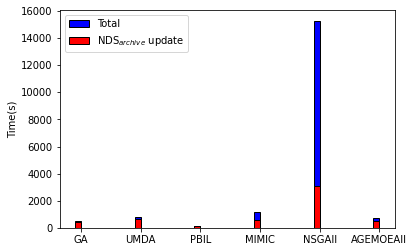

```
Mean percentage of total time used to update NDS_archive in each algorithm. Dataset: s1.
geneticNDS: 95.33%
umda: 75.88%
pbil: 88.98%
mimic: 55.75%
nsgaii: 19.75%
agemoea2: 66.36%
```

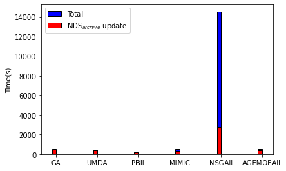

```
Mean percentage of total time used to update NDS_archive in each algorithm. Dataset: s2.
geneticNDS: 97.03%
umda: 83.49%
pbil: 89.53%
mimic: 49.88%
nsgaii: 20.04%
agemoea2: 77.47%
```

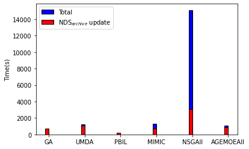

```
Mean percentage of total time used to update NDS_archive in each algorithm. Dataset: s3.
geneticNDS: 96.05%
umda: 78.78%
pbil: 87.37%
mimic: 41.84%
nsgaii: 19.59%
agemoea2: 78.87%
```

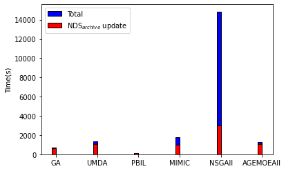

```
Mean percentage of total time used to update NDS_archive in each algorithm. Dataset: s4.
geneticNDS: 96.54%
umda: 81.46%
pbil: 88.8%
mimic: 32.61%
nsgaii: 19.98%
agemoea2: 78.02%
```

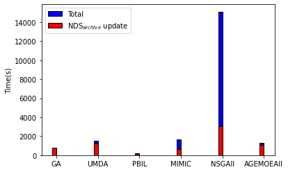

#### 4.2 Total time with SSS once Vs Total time with SSS per iteration

```
MEAN VALUES
```

|  | Algorithm | % delta | time before | time after | wilcox paired test |
| --- | --- | --- | --- | --- | --- |
| 0 | GA | 60.1100 | 254.6800 | 84.7600 | 5.96E-08 |
| 1 | UMDA | 17.9900 | 214.1800 | 166.5500 | 5.96E-08 |
| 2 | PBIL | 27.3500 | 112.7400 | 64.7800 | 2.98E-07 |
| 3 | MIMIC | 11.3200 | 236.1200 | 194.0200 | 3.81E-05 |
| 4 | AGEMOEAII | 16.5000 | 296.9500 | 241.0400 | 5.96E-08 |

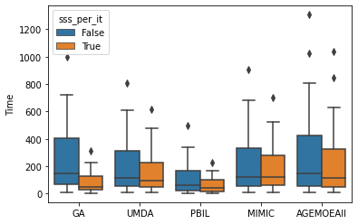

```
MEAN VALUES
```

|  | Algorithm | % delta | time before | time after | wilcox paired test |
| --- | --- | --- | --- | --- | --- |
| 0 | GA | 68.9500 | 474.3500 | 110.6500 | 5.96E-08 |
| 1 | UMDA | 43.6000 | 781.3900 | 402.4400 | 5.96E-08 |
| 2 | PBIL | 50.9100 | 132.8500 | 52.6600 | 5.96E-08 |
| 3 | MIMIC | 24.4400 | 1201.0800 | 926.4700 | 5.96E-08 |
| 4 | AGEMOEAII | 33.1100 | 699.2500 | 431.1600 | 5.96E-08 |

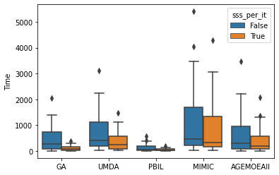

```
MEAN VALUES
```

|  | Algorithm | % delta | time before | time after | wilcox paired test |
| --- | --- | --- | --- | --- | --- |
| 0 | GA | 76.1400 | 517.9200 | 92.7600 | 5.96E-08 |
| 1 | UMDA | 32.3500 | 512.5200 | 308.6500 | 5.96E-08 |
| 2 | PBIL | 49.3300 | 181.0200 | 65.7900 | 5.96E-08 |
| 3 | MIMIC | 18.6300 | 536.4100 | 433.9300 | 5.96E-08 |
| 4 | AGEMOEAII | 20.0900 | 571.3100 | 402.2300 | 1.97E-06 |

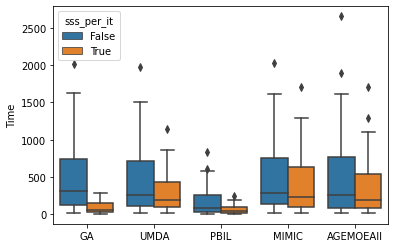

```
MEAN VALUES
```

|  | Algorithm | % delta | time before | time after | wilcox paired test |
| --- | --- | --- | --- | --- | --- |
| 0 | GA | 82.6400 | 717.0000 | 85.3100 | 5.96E-08 |
| 1 | UMDA | 56.1600 | 1241.4200 | 478.5100 | 5.96E-08 |
| 2 | PBIL | 49.9600 | 184.1700 | 70.3500 | 5.96E-08 |
| 3 | MIMIC | 27.3300 | 1315.5100 | 948.8700 | 5.96E-08 |
| 4 | AGEMOEAII | 38.6700 | 1101.5000 | 553.8300 | 5.96E-08 |

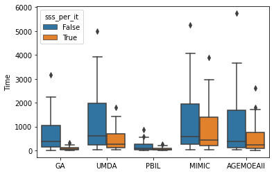

```
MEAN VALUES
```

|  | Algorithm | % delta | time before | time after | wilcox paired test |
| --- | --- | --- | --- | --- | --- |
| 0 | GA | 75.2300 | 670.1000 | 115.3100 | 5.96E-08 |
| 1 | UMDA | 45.7600 | 1318.4800 | 686.1600 | 5.96E-08 |
| 2 | PBIL | 55.1100 | 146.5600 | 53.8900 | 5.96E-08 |
| 3 | MIMIC | 32.1900 | 1769.9100 | 1012.2500 | 5.96E-08 |
| 4 | AGEMOEAII | 51.2400 | 1298.8800 | 494.5700 | 5.96E-08 |

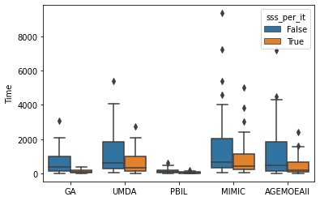

```
MEAN VALUES
```

|  | Algorithm | % delta | time before | time after | wilcox paired test |
| --- | --- | --- | --- | --- | --- |
| 0 | GA | 78.1900 | 775.4500 | 109.4800 | 5.96E-08 |
| 1 | UMDA | 52.5400 | 1523.2000 | 695.8900 | 5.96E-08 |
| 2 | PBIL | 57.0800 | 173.5700 | 61.6800 | 5.96E-08 |
| 3 | MIMIC | 25.9900 | 1645.4700 | 1158.5800 | 5.96E-08 |
| 4 | AGEMOEAII | 49.6300 | 1310.5900 | 510.4000 | 5.96E-08 |

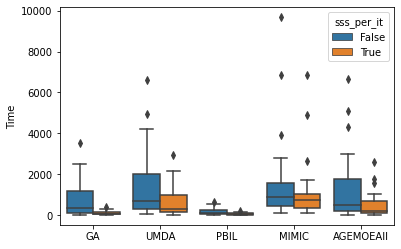

### 4.3 Change in HV, spread and UNFR, after applying SSS per iteration instead of only once at the end.

#### 4.3.1 Change in HV

```
Change in HV (positive percent is worse):
MEAN VALUES
```

|  | Algorithm | % delta | HV before | HV after | wilcox paired test |
| --- | --- | --- | --- | --- | --- |
| 0 | GA | 0.0100 | 0.9394 | 0.9393 | 1.19E-07 |
| 1 | UMDA | 0.0100 | 0.9722 | 0.9721 | 3.19E-05 |
| 2 | PBIL | -1.3100 | 0.9568 | 0.9691 | 5.96E-08 |
| 3 | MIMIC | 0.0000 | 0.9924 | 0.9924 | 3.45E-01 |
| 4 | AGEMOEAII | 0.0000 | 0.9863 | 0.9863 | 8.08E-05 |

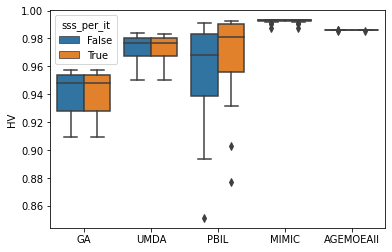

```
MEAN VALUES
```

|  | Algorithm | % delta | HV before | HV after | wilcox paired test |
| --- | --- | --- | --- | --- | --- |
| 0 | GA | 0.0500 | 0.6962 | 0.6958 | 5.96E-08 |
| 1 | UMDA | 0.2000 | 0.8058 | 0.8042 | 5.96E-08 |
| 2 | PBIL | -11.5500 | 0.5354 | 0.5981 | 5.96E-08 |
| 3 | MIMIC | 0.1800 | 0.8337 | 0.8323 | 5.96E-08 |
| 4 | AGEMOEAII | 0.0500 | 0.8105 | 0.8101 | 8.17E-06 |

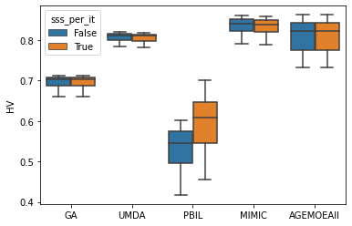

```
MEAN VALUES
```

|  | Algorithm | % delta | HV before | HV after | wilcox paired test |
| --- | --- | --- | --- | --- | --- |
| 0 | GA | 0.0500 | 0.7616 | 0.7613 | 5.96E-08 |
| 1 | UMDA | 0.0400 | 0.8428 | 0.8425 | 1.23E-05 |
| 2 | PBIL | -6.7100 | 0.7315 | 0.7799 | 5.96E-08 |
| 3 | MIMIC | 0.0600 | 0.8741 | 0.8736 | 5.96E-08 |
| 4 | AGEMOEAII | 0.0100 | 0.8742 | 0.8741 | 1.73E-03 |

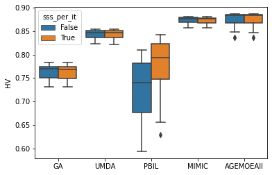

```
MEAN VALUES
```

|  | Algorithm | % delta | HV before | HV after | wilcox paired test |
| --- | --- | --- | --- | --- | --- |
| 0 | GA | 0.0500 | 0.6696 | 0.6693 | 5.96E-08 |
| 1 | UMDA | 0.1700 | 0.7684 | 0.7670 | 5.96E-08 |
| 2 | PBIL | -11.4600 | 0.5358 | 0.5976 | 5.96E-08 |
| 3 | MIMIC | 0.1400 | 0.7856 | 0.7844 | 5.96E-08 |
| 4 | AGEMOEAII | 0.0400 | 0.7715 | 0.7711 | 4.89E-04 |

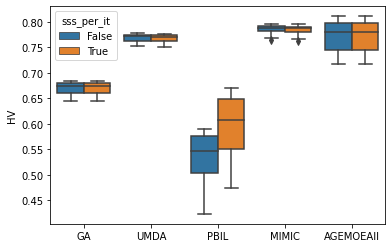

```
MEAN VALUES
```

|  | Algorithm | % delta | HV before | HV after | wilcox paired test |
| --- | --- | --- | --- | --- | --- |
| 0 | GA | 0.0500 | 0.6649 | 0.6646 | 5.96E-08 |
| 1 | UMDA | 0.2300 | 0.7794 | 0.7776 | 5.96E-08 |
| 2 | PBIL | -12.0000 | 0.4705 | 0.5273 | 5.96E-08 |
| 3 | MIMIC | 0.2000 | 0.7986 | 0.7970 | 5.96E-08 |
| 4 | AGEMOEAII | 0.0600 | 0.7677 | 0.7673 | 5.96E-08 |

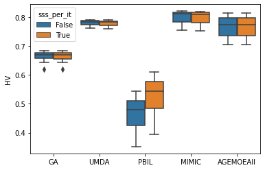

```
MEAN VALUES
```

|  | Algorithm | % delta | HV before | HV after | wilcox paired test |
| --- | --- | --- | --- | --- | --- |
| 0 | GA | 0.0700 | 0.6305 | 0.6301 | 2.98E-07 |
| 1 | UMDA | 0.2600 | 0.7533 | 0.7514 | 5.96E-08 |
| 2 | PBIL | -12.1400 | 0.4209 | 0.4724 | 5.96E-08 |
| 3 | MIMIC | 0.2900 | 0.7616 | 0.7594 | 5.96E-08 |
| 4 | AGEMOEAII | 0.0500 | 0.7152 | 0.7149 | 6.56E-06 |

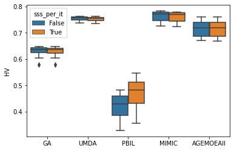

#### 4.3.2 Change in Spread

```
Change in spread (positive percent is better):
MEAN VALUES
```

|  | Algorithm | % delta | spread before | spread after | wilcox paired test |
| --- | --- | --- | --- | --- | --- |
| 0 | GA | -1.2400 | 0.6353 | 0.6432 | 2.56E-06 |
| 1 | UMDA | -0.5400 | 0.5893 | 0.5924 | 2.55E-02 |
| 2 | PBIL | 4.1100 | 0.6137 | 0.5879 | 6.73E-03 |
| 3 | MIMIC | -0.0500 | 0.5267 | 0.5269 | 2.25E-01 |
| 4 | AGEMOEAII | -0.0300 | 0.6383 | 0.6385 | 3.48E-01 |

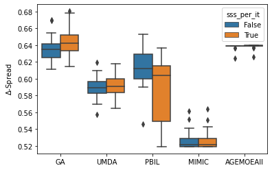

```
MEAN VALUES
```

|  | Algorithm | % delta | spread before | spread after | wilcox paired test |
| --- | --- | --- | --- | --- | --- |
| 0 | GA | -3.0500 | 0.7216 | 0.7436 | 5.96E-08 |
| 1 | UMDA | -6.7800 | 0.5960 | 0.6362 | 5.96E-08 |
| 2 | PBIL | -1.4100 | 0.5801 | 0.5879 | 1.07E-01 |
| 3 | MIMIC | -2.2200 | 0.6105 | 0.6238 | 1.45E-03 |
| 4 | AGEMOEAII | -1.0600 | 0.6202 | 0.6265 | 3.93E-02 |

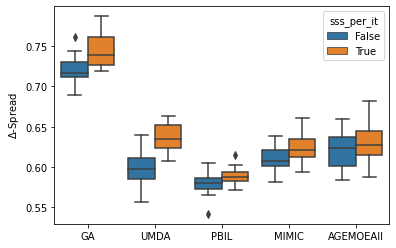

```
MEAN VALUES
```

|  | Algorithm | % delta | spread before | spread after | wilcox paired test |
| --- | --- | --- | --- | --- | --- |
| 0 | GA | -1.6000 | 0.6431 | 0.6533 | 1.97E-06 |
| 1 | UMDA | -2.1400 | 0.5928 | 0.6054 | 1.23E-05 |
| 2 | PBIL | 0.7400 | 0.5917 | 0.5867 | 2.41E-01 |
| 3 | MIMIC | -0.5400 | 0.5786 | 0.5816 | 1.82E-01 |
| 4 | AGEMOEAII | -0.2400 | 0.5366 | 0.5378 | 1.36E-01 |

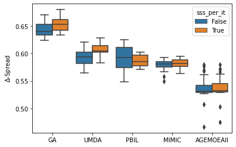

```
MEAN VALUES
```

|  | Algorithm | % delta | spread before | spread after | wilcox paired test |
| --- | --- | --- | --- | --- | --- |
| 0 | GA | -0.2900 | 0.6416 | 0.6434 | 3.12E-01 |
| 1 | UMDA | -2.9200 | 0.5945 | 0.6115 | 1.51E-05 |
| 2 | PBIL | -0.8200 | 0.5876 | 0.5922 | 1.73E-01 |
| 3 | MIMIC | -2.1200 | 0.6050 | 0.6177 | 1.51E-05 |
| 4 | AGEMOEAII | -1.0200 | 0.6030 | 0.6090 | 2.36E-02 |

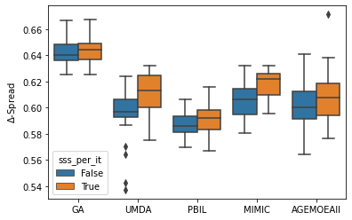

```
MEAN VALUES
```

|  | Algorithm | % delta | spread before | spread after | wilcox paired test |
| --- | --- | --- | --- | --- | --- |
| 0 | GA | -0.7800 | 0.7021 | 0.7075 | 5.58E-03 |
| 1 | UMDA | -6.9300 | 0.5685 | 0.6077 | 5.96E-08 |
| 2 | PBIL | -2.0600 | 0.5850 | 0.5969 | 5.56E-04 |
| 3 | MIMIC | -3.4700 | 0.5997 | 0.6204 | 8.34E-07 |
| 4 | AGEMOEAII | -0.8300 | 0.6120 | 0.6170 | 1.34E-01 |

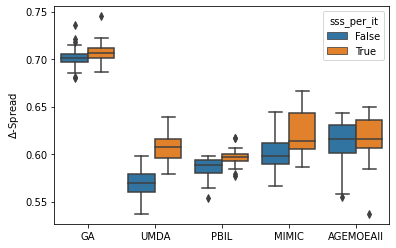

```
MEAN VALUES
```

|  | Algorithm | % delta | spread before | spread after | wilcox paired test |
| --- | --- | --- | --- | --- | --- |
| 0 | GA | -0.4600 | 0.6922 | 0.6953 | 5.58E-03 |
| 1 | UMDA | -5.5900 | 0.5709 | 0.6027 | 5.96E-08 |
| 2 | PBIL | -2.2000 | 0.5797 | 0.5922 | 6.31E-04 |
| 3 | MIMIC | -4.2200 | 0.5997 | 0.6251 | 8.34E-07 |
| 4 | AGEMOEAII | 1.4500 | 0.6236 | 0.6141 | 3.67E-02 |

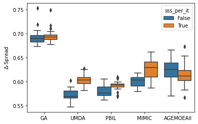

#### 4.3.3 Change in UNFR

```
Change in UNFR (negative percent is better):
MEAN VALUES
```

|  | Algorithm | % delta | unfr before | unfr after | wilcox paired test |
| --- | --- | --- | --- | --- | --- |
| 0 | GA | -1.7000 | 0.1324 | 0.1346 | 1.19E-07 |
| 1 | UMDA | -0.8300 | 0.1442 | 0.1453 | 3.10E-04 |
| 2 | PBIL | -3.5000 | 0.1715 | 0.1775 | 2.56E-06 |
| 3 | MIMIC | -0.0200 | 0.1880 | 0.1880 | 6.55E-01 |
| 4 | AGEMOEAII | 0.1100 | 0.1154 | 0.1152 | 2.53E-02 |

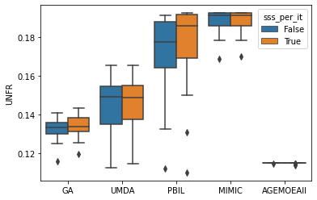

```
MEAN VALUES
```

|  | Algorithm | % delta | unfr before | unfr after | wilcox paired test |
| --- | --- | --- | --- | --- | --- |
| 0 | GA | -26.4400 | 0.0032 | 0.0039 | 1.81E-05 |
| 1 | UMDA | -21.6000 | 0.0032 | 0.0038 | 5.96E-08 |
| 2 | PBIL | 70.1000 | 0.0007 | 0.0001 | 3.41E-04 |
| 3 | MIMIC | -9.8900 | 0.0036 | 0.0041 | 6.55E-04 |
| 4 | AGEMOEAII | 4.4000 | 0.0028 | 0.0026 | 6.67E-02 |

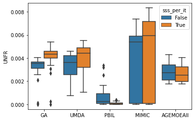

```
MEAN VALUES
```

|  | Algorithm | % delta | unfr before | unfr after | wilcox paired test |
| --- | --- | --- | --- | --- | --- |
| 0 | GA | -8.5600 | 0.0146 | 0.0158 | 5.96E-08 |
| 1 | UMDA | -6.4000 | 0.0208 | 0.0220 | 5.96E-08 |
| 2 | PBIL | 7.1400 | 0.0325 | 0.0305 | 4.17E-06 |
| 3 | MIMIC | -2.9600 | 0.0322 | 0.0332 | 1.19E-07 |
| 4 | AGEMOEAII | 3.4600 | 0.0388 | 0.0379 | 8.77E-05 |

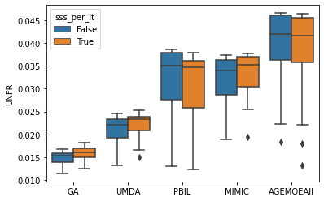

```
MEAN VALUES
```

|  | Algorithm | % delta | unfr before | unfr after | wilcox paired test |
| --- | --- | --- | --- | --- | --- |
| 0 | GA | -8.5800 | 0.0022 | 0.0024 | 8.00E-05 |
| 1 | UMDA | -15.2300 | 0.0032 | 0.0036 | 5.96E-08 |
| 2 | PBIL | 55.6600 | 0.0027 | 0.0009 | 4.03E-05 |
| 3 | MIMIC | -14.6500 | 0.0032 | 0.0037 | 4.92E-05 |
| 4 | AGEMOEAII | 1.5700 | 0.0067 | 0.0066 | 1.01E-01 |

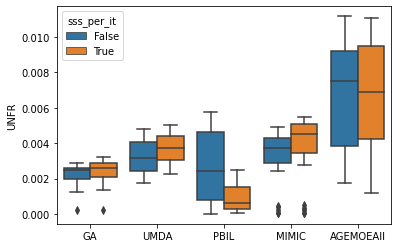

```
MEAN VALUES
```

|  | Algorithm | % delta | unfr before | unfr after | wilcox paired test |
| --- | --- | --- | --- | --- | --- |
| 0 | GA | -18.3600 | 0.0012 | 0.0014 | 5.93E-05 |
| 1 | UMDA | -27.6800 | 0.0013 | 0.0016 | 5.96E-08 |
| 2 | PBIL | 35.7500 | 0.0001 | 0.0001 | 1.13E-02 |
| 3 | MIMIC | -10.5600 | 0.0014 | 0.0017 | 1.47E-03 |
| 4 | AGEMOEAII | 1.2400 | 0.0037 | 0.0037 | 5.97E-01 |

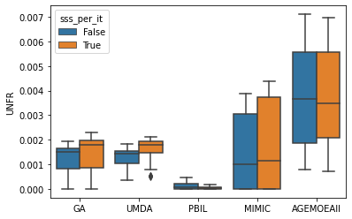

```
MEAN VALUES
```

|  | Algorithm | % delta | unfr before | unfr after | wilcox paired test |
| --- | --- | --- | --- | --- | --- |
| 0 | GA | -16.9400 | 0.0007 | 0.0008 | 2.91E-04 |
| 1 | UMDA | -40.6100 | 0.0007 | 0.0009 | 2.06E-05 |
| 2 | PBIL | 46.3100 | 0.0002 | 0.0001 | 1.81E-03 |
| 3 | MIMIC | -3.0300 | 0.0004 | 0.0005 | 9.69E-02 |
| 4 | AGEMOEAII | -3.3000 | 0.0019 | 0.0019 | 3.94E-01 |

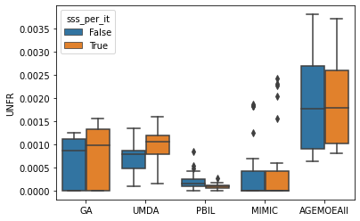